# Seed germination

## Meta-analysis

For different species, we have data on germination percentage:

- across time
- across different treatments (e.g. higher temperature, etc.)

## Generative model

Let’s first consider one seed.

Our first hypothesis is that all seeds cannot germinate (they are not all *viable*).  
This is a latent state!

Let $V_{k,s}$ be this latent viability for a seed $k$ (from a species $s$):

$V_{k,s} \sim Bernoulli(p_{s})$

## Generative model

Then let $G_{k,s}(t)$ be the germination at time t for this seed:

$\mathbb{P}(G_{k,s}(t \leq \text{T}) ~|~ V_{k,s} = 1) = \text{F}_s(\text{T})$

We note $\text{F}_s$ the CDF with some species-specific parameters.

We observe germination in discrete intervals, so we would rather look at: $\mathbb{P}(G_{k,s}(t \in~ ]\text{T}-1, \text{T}] ~) ~|~ V_{k,s} = 1) = \text{F}_s(\text{T}) - \text{F}_s(\text{T}-1)$

## Generative model

If we marginalize over the latent $V_{k,s}$:

$$\begin{equation}
\begin{split}
\mathbb{P}(G_{k,s}(t \in~ ]\text{T}-1, \text{T}] ~) & = \mathbb{P}(G_{k,s}(t \in~ ]\text{T}-1, \text{T}] ~) ~\cap~ V_{k,s} = 0) \\
& + \mathbb{P}(G_{k,s}(t \in~ ]\text{T}-1, \text{T}] ~) ~\cap~ V_{k,s} = 1) \\
& = \mathbb{P}(V_{k,s} = 1) \times \mathbb{P}(G_{k,s}(t \in~ ]\text{T}-1, \text{T}] ~) ~|~ V_{k,s} = 1) \\
& = p_{s} \times (~ \text{F}_s(\text{T}) - \text{F}_s(\text{T}-1) ~)
\end{split}
\end{equation}$$

## Generative model

The germination trials are not ran for an infinite amount of time, but only until $\text{T}_\text{max}$.  
The observations are thus censored!

The probability the seed never germinates is:

$$\begin{equation}
\begin{split}
(1-p_{s}) + p_{s} \times \mathbb{P}(G_{k,s}(t > \text{T}_\text{max} ~) ~|~ V_{k,s} = 1) = \\
(1-p_{s}) + p_{s} \times (1 - \text{F}_s(\text{T}_\text{max}) )
\end{split}
\end{equation}$$

## Generative model

Let’s note:

$\theta_0 = (1-p_{s}) + p_{s} \times (1 - \text{F}_s(\text{T}_\text{max}) )$  
$\forall t \in [\![1,\text{T}_\text{max}]\!]$  
$~~ \theta_t = p_{s} \times (~ \text{F}_s(\text{t}) - \text{F}_s(\text{t}-1) ~)$

We do not observe only one seed $k$, but $N$ seeds:
$$\begin{equation}
\begin{split}
Y_{s} = (&\text{seeds that never germinated}, \text{seeds germinated at time 1}, \\
& \dots, \\
& \text{seeds germinated at time} ~\text{T}_\text{max}
)
\end{split}
\end{equation}$$

$Y_{s} \sim \text{Multinomial}(\theta_0, \theta_1, \dots, \theta_{\text{T}_\text{max}})$

## Which CDF?

We have to choose a functional form for $\text{F}_s(\text{T})$ that makes sense (with our domain expertise).

For example, if we expect a constant rate of germination with time, we would use an exponential, etc.  
Here we will start with a Gompertz curve: $\text{F}_s(\text{T}) = \exp \left(-\log(2) \times \exp \left(-\frac{2}{\log(2)} \times \beta \times (t - \tau) \right) \right)$

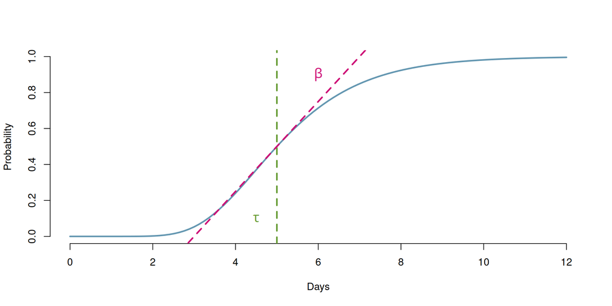

## Stan code

```stan
functions {
  real gompertz(real t, real beta, real tau) {
    return exp(-log2() * exp( -(2 / log2())
    * beta * (t - tau)));
  }
}

data {
  int<lower=1> Ntimes; // number of discrete intervals
  int<lower=0> d[Ntimes]; // day of obs., d at Ntimes = Tmax
  int<lower=0> y[Ntimes+1]; // first element is #seeds that never germinated
}

parameters {
  real<lower=0, upper=1> pv; // probability of viability
  real<lower=0> beta; // beta > 0? that's my expectation
  real<lower=0> tau;
}

transformed parameters {
  vector<lower=0>[Ntimes+1] theta; //germination prob

  theta[2] = pv*(gompertz(d[1], beta, tau) - gompertz(0, beta, tau));
  for (t in 2:Ntimes) {
    theta[t+1] = pv*(gompertz(d[t], beta, tau) - gompertz(d[t-1], beta, tau));
  }

  theta[1] = (1-pv)+pv*(1-gompertz(d[Ntimes], beta, tau));

  theta = theta / sum(theta); //  for stability

}

model {
  // priors, au pif
  pv ~ beta(4,2);
  tau ~ normal(10,3);
  beta ~ normal(0,0.5/2.57);

  // likelihood
  y ~ multinomial(theta);
}

generated quantities {
  int<lower=0> y_pred[Ntimes+1];

  y_pred = multinomial_rng(theta, sum(y));
}
```

## Simulate data

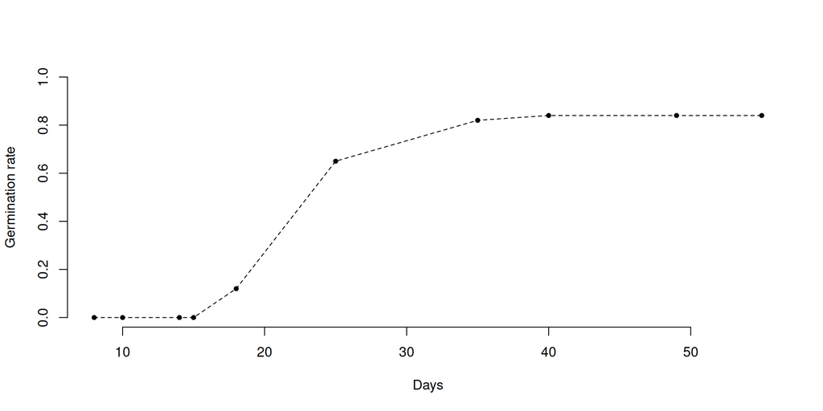

## Fit model on simulated data

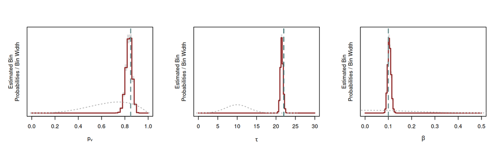

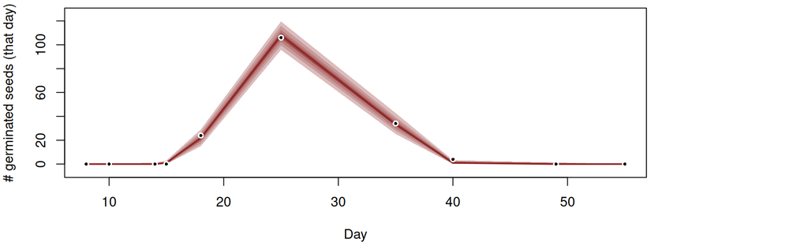

## Questions

- does this approach sound good to you?
- what to do when we don’t know the number of seeds $N$ (i.e. we only have the %)
- domain expertise: what are you expectations in terms of treatment effects? on $p_{s}$, $\beta$, $\tau$…